# Proposal- Vancouver Crime Tracker

Chimaobi Amadi, Elliott Ribner, Shivam Verma, Xugang Zhong(Kirk)

22/11/2019

## Description of the Data

The dataset is obtained from the [Vancouver Police Department (VPD) website](https://geodash.vpd.ca/opendata/). It is based on the VPD Records Management System and contains information about the type of crime, nearest block, nearest neighborhood and date & time of the crime. The data contains information from 1st January 2003 to 31st October 2019. VPD aims to provide this data for the public interest, to enhance awareness & maintain transparency about crimes in Vancouver. Please note that the dataset does not include all the crimes because of privacy & investigative reasons. Location information in the data was offset so that no association with a specific person or property can be made.

### Variable Description

[output not shown]

## Research Questions and Usage Scenarios

Peter and his family plans to relocate to Canada. As a result of the favourable weather condition in Vancouver, they decide to settle in Vancouver. Their first goal is to find accommodation: renting and eventually owning a house in a safe neighbourhood, as well as safety for their kids especially at school. The family does not know anyone in Vancouver and relies on a reliable source of information regarding the crime situation and trend in each of the neighbourhoods in Vancouver.

There are many people like Peter and his family; and to help solve their problem, we plan on creating an interactive app that has the capability of displaying crime information at a glance. The secondary motivation for this app is answer general crime trends in Vancouver and create awareness about crime rates per neighbourhood and need for drastic intervention.

Using the dataset provided by the Vancouver Police Department (VPD), we will build an interactive dashboard with the historic crime situation in the city from 2003 to 2019. There are 3 filters provided in the dashboard which includes the neighborhood, type of crime and the period in years. The filter option streamlines the visualization and produces charts that answer the questions.

The filtered data is molded to show the crime occurrences by Month-of-Year (*Chart 1*) & Time-of-Day (*Chart 2*) to help him understand the behavior of crimes around the city. In addition to this, he can look at the trend of crime rate by year (*Chart 3*) and get to know the composition of crimes (*Chart 4*) as well.

## Sketch of the Application

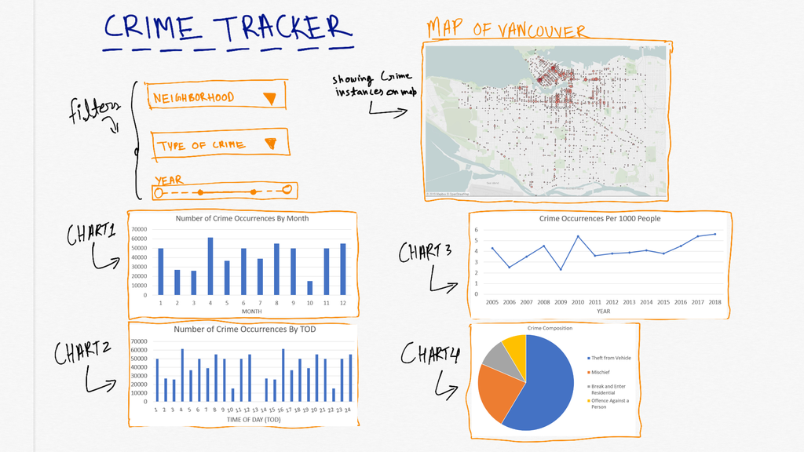

Sketch